# How real is Racing Louisville?: Part 2

7/15/2025

[Back to home](https://ajsportstat.github.io/nwsl-2025)

The 2025 NWSL season has come with a lot of surprises. The San Diego Wave and the Portland Thorns are both massively out-performing preseason predictions, while Gotham FC, the North Carolina Courage, and Bay FC are all finishing out the first half of the season lower than many would have expected. All of these teams have ended up in many different table positions, however, but Racing Louisville has quite literally never finished a season outside of 9th place. Their current position of 7th place (just 5 points shy of 2nd), along with their most recent statement victory over 2024 NWSL champions and shield winners Orlando Pride, has had me wondering just how real this team really is, and whether this will be the season they finally finish above 9th and make it into the playoffs.

This is the second part of a 2 part series where I use hypothesis tests to determine whether Racing Louisville is in fact the real deal this season. In part 1 [here](https://www.ajsportstat.github.io/nwsl-2025/teams/louisvillept1.html), I compared Louisville’s 2025 season to their 2024 season and determined that they are overall having a better season this year than last. In this part, I will be comparing the 2025 Racing Louisville season to that of the Seattle Reign, a team that is 1 point and 1 table spot above them halfway through the season.

There are a three important statistics that will come out of each test: an actual difference in means, a t statistic (which is sort of an estimate of the true difference between the means that also takes into account variability within a sample), and a p-value (which is essentially a measure of how likely it is that the null hypothesis is true). So, a lower p-value in this case would indicate a higher likelihood that there is a statistically significant difference between the means. Typically p-values under 0.05 are considered a statistically significant change, and in some cases p-values up to 0.10 are accepted. I’ll go into this on a case-by-case basis.

**Realm 1: Offense**

The first thing I’m going to look at is whether the team is better offensively than their peer this season. I’m going to look at a few different metrics here: goals, xG, shots/shots on target, touches in the final third, and attempted/successful take-ons.

*Hypothesis test 1: Goals scored*

Null hypothesis: Louisville is not scoring more goals than Seattle this season.

Alternative hypothesis: Louisville is scoring more goals than Seattle this season.

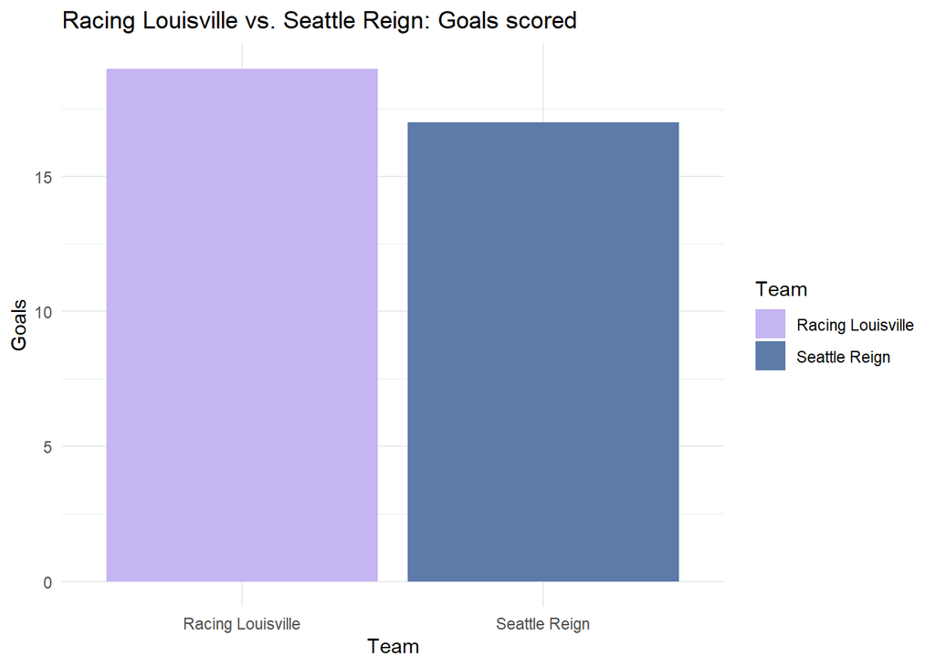

Louisville has scored more goals–let’s see if it’s statistically significant.

| Dependent Variable | t | df | p | d | 95% CI |
| --- | --- | --- | --- | --- | --- |
| Goals | 0.36 | 23.82 | .360 | 0.14 | [-0.63, 0.91] |

A quick note on how to interpret these results: “t” refers to the t statistic I discussed earlier; “df” refers to “degrees of freedom”, which is a measure used to calculate significance that you don’t need to worry about; “p” is the p-value, aka what we will be using to determine statistical significance; “d” refers to Cohen’s d, a measure of the difference between the group means that is essentially standardized to be the same “unit” for all variables (0.2 is a small effect, 0.5 is a medium effect, and 0.8 is a large effect); and “95% CI” refers to a “95% confidence interval”–in this case, that means that the model is 95% confident that the true difference between these two groups lies within these two numbers, but the range has to be quite big to encapsulate 95% certainty, so it’s not of much help to us here.

So Louisville is scoring more goals, but not statistically significantly so.

*Hypothesis test 2: xG*

Null hypothesis: Louisville is not generating more xG than Seattle this season.

Alternative hypothesis: Louisville is generating more xG than Seattle this season.

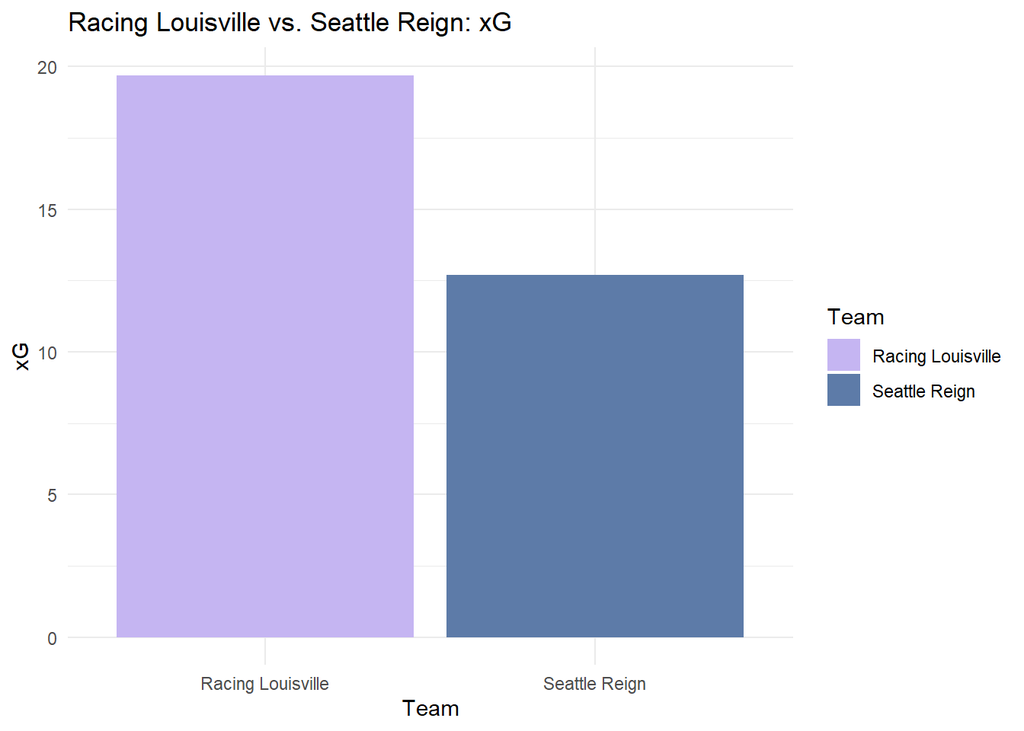

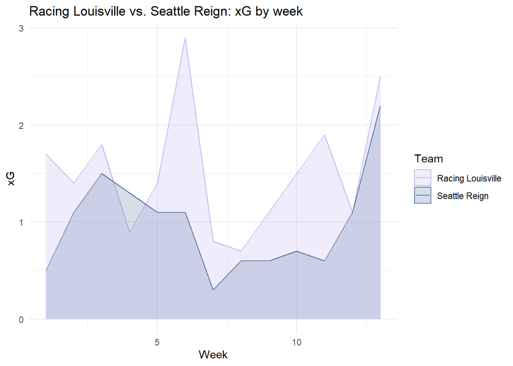

That looks like a lot more xG on the part of Racing Louisville, but is it actually?

| Dependent Variable | t | df | p | d | 95% CI |
| --- | --- | --- | --- | --- | --- |
| xG | 2.35 | 22.71 | .014* | 0.92 | [0.10, 1.72] |

Yes! That is very statistically significant. **Racing Louisville is generating more xG this season than the Seattle Reign**.

*Hypothesis test 3: Shots*

Null hypothesis: Louisville is not taking more shots than Seattle this season.

Alternative hypothesis: Louisville is taking more shots than Seattle this season.

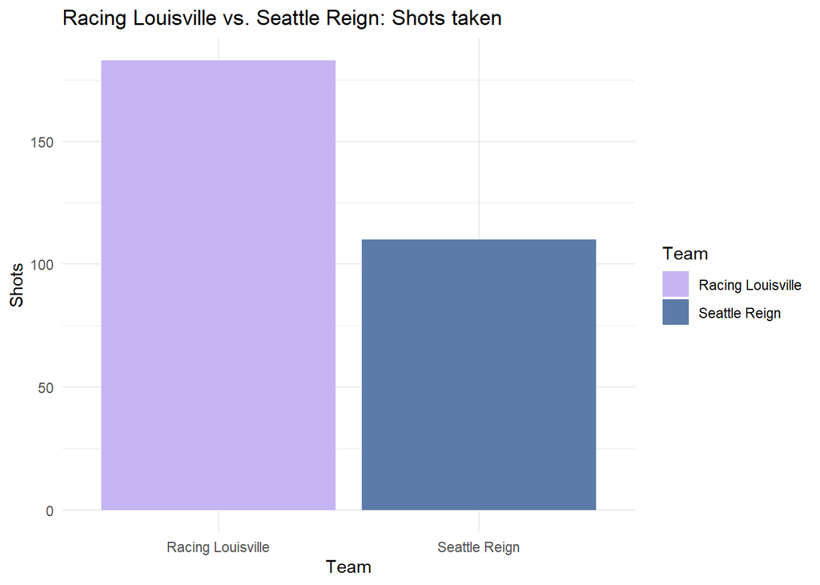

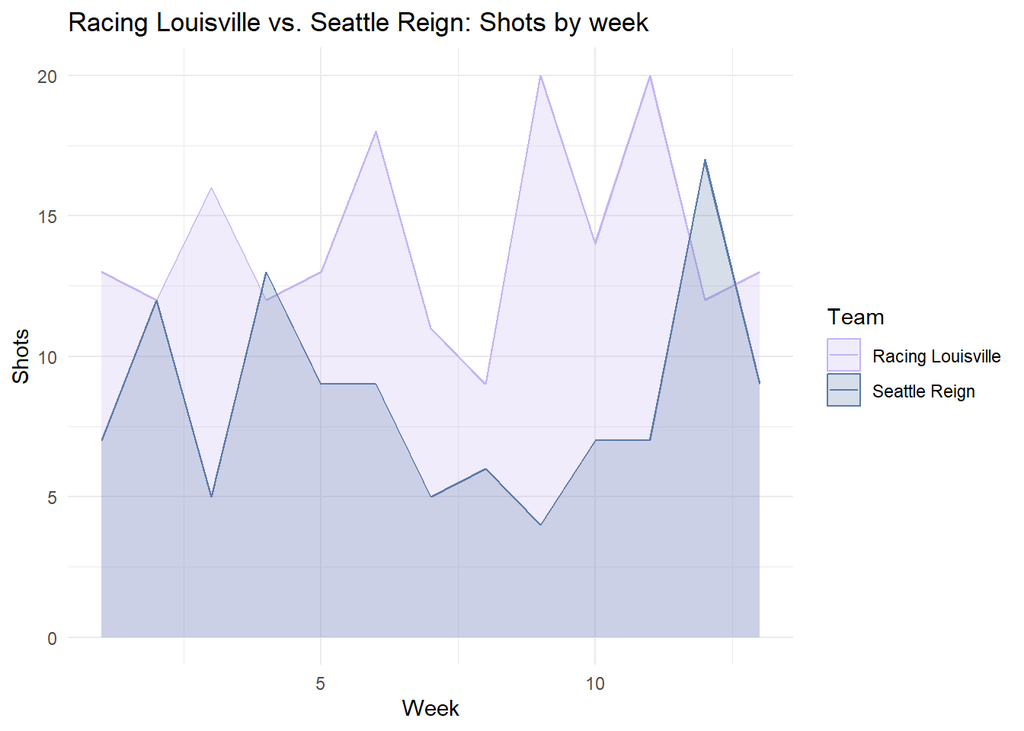

Racing Louisville appear to be taking more shots, averaging 5.6 more shots per game than Seattle this season.

| Dependent Variable | t | df | p | d | 95% CI |
| --- | --- | --- | --- | --- | --- |
| Shots | 4.02 | 23.87 | < .001*** | 1.58 | [0.68, 2.45] |

That is the most statistically significant it gets! **Racing Louisville is taking more shots this season than Seattle**.

*Hypothesis test 4: Shots on target*

Null hypothesis: Louisville’s shot on target percent is not higher than Seattle’s this season.

Alternative hypothesis: Louisville’s shot on target percent is higher Seattle’s this season.

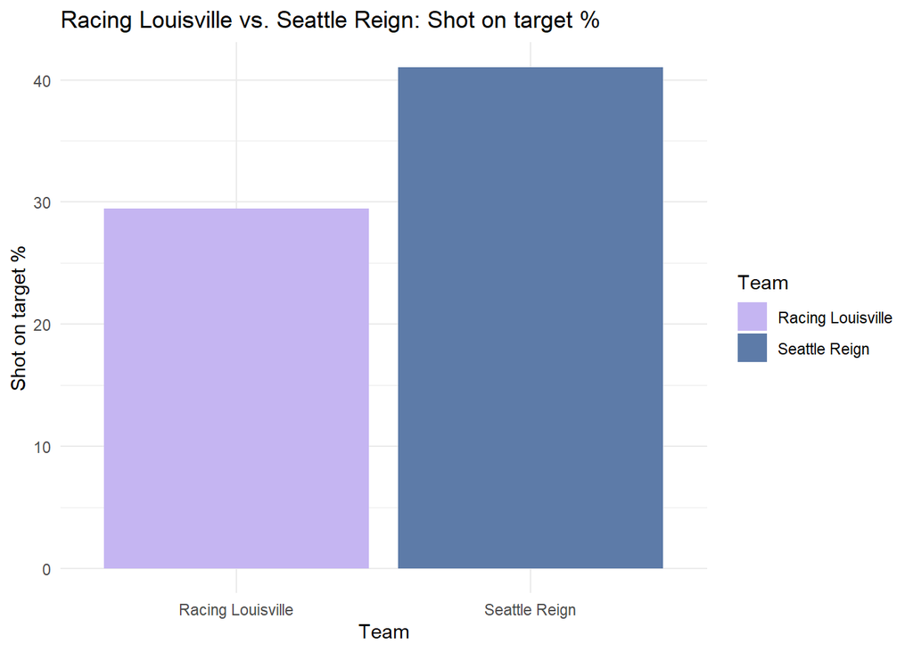

Racing Louisville has a worse shot on target percentage than the Reign–let’s take a look at just how much worse it is.

| Dependent Variable | t | df | p | d | 95% CI |
| --- | --- | --- | --- | --- | --- |
| Shot_on_Target_Pct | -1.73 | 23.55 | .952 | -0.68 | [-1.46, 0.12] |

Unfortunately, it’s actually statistically significant in the other direction. That is, **Racing Louisville has a lower percentage of shots on target than the Seattle Reign**.

*Hypothesis test 5: xG per shot*

Null hypothesis: Louisville is not creating more xG per shot than Seattle this season.

Alternative hypothesis: Louisville is creating more xG per shot than Seattle this season.

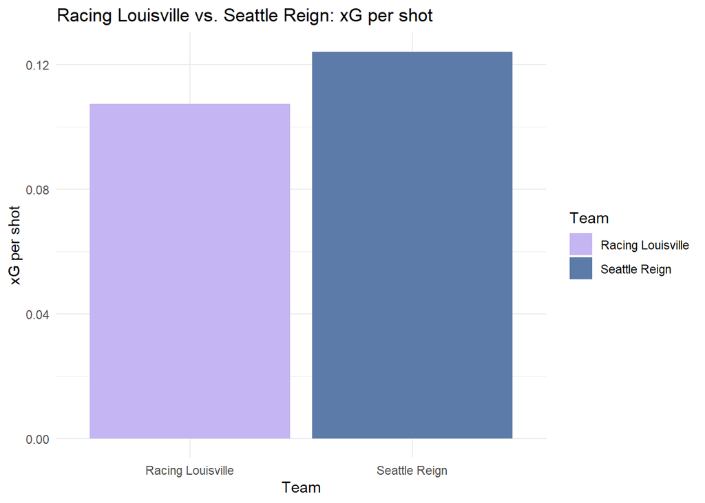

Louisville is generating less xG per shot than Seattle.

| Dependent Variable | t | df | p | d | 95% CI |
| --- | --- | --- | --- | --- | --- |
| xG_per_Shot | -0.75 | 18.23 | .768 | -0.29 | [-1.06, 0.48] |

It’s not statistically significant in either direction, but on the whole we’re seeing less xG per shot from Racing Louisville than Seattle. But again, Louisville has taken many many more shots.

*Hypothesis test 6: Final third touches*

Null hypothesis: Louisville has not had more touches in the final third than Seattle this season.

Alternative hypothesis: Louisville has had more touches in the final third than Seattle this season.

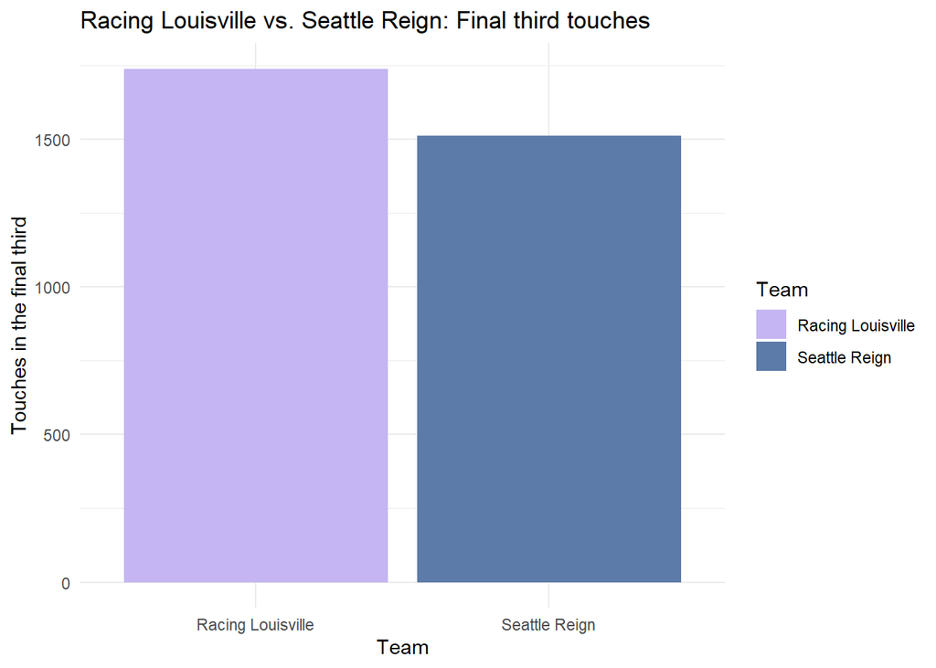

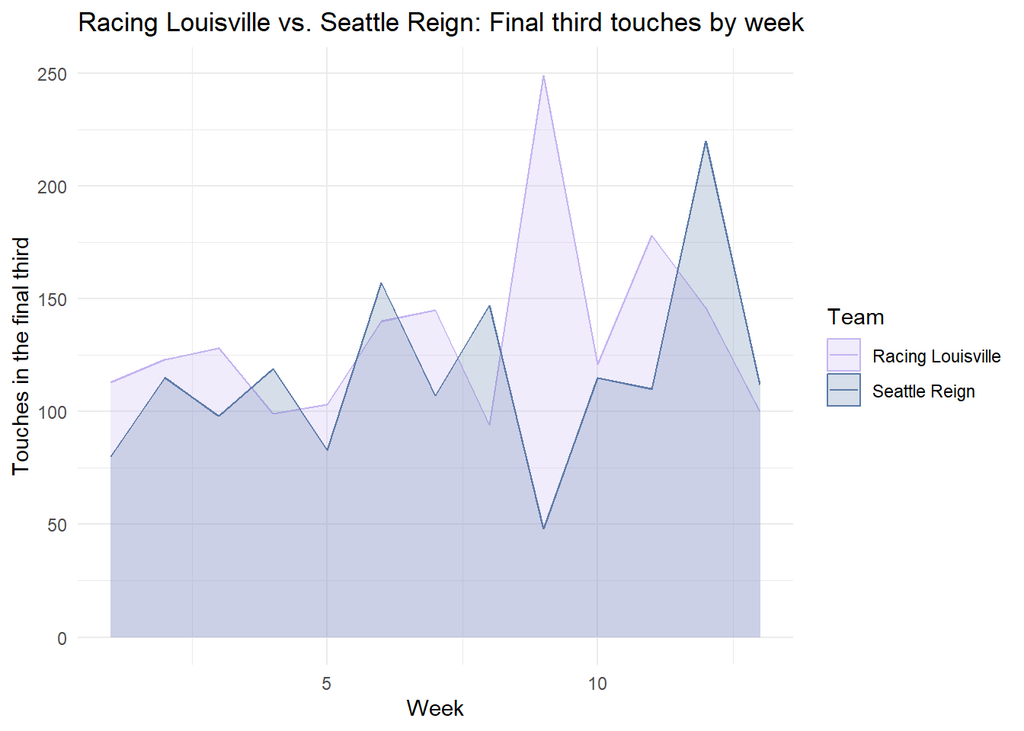

Louisville overall has more final third touches than the Reign.

| Dependent Variable | t | df | p | d | 95% CI |
| --- | --- | --- | --- | --- | --- |
| Final_Third_Touches | 1.07 | 24.00 | .148 | 0.42 | [-0.36, 1.19] |

However, it is not quite statistically significant.

*Hypothesis test 7: Take-ons*

Null hypothesis: Louisville is not attempting more take-ons than Seattle this season.

Alternative hypothesis: Louisville is attempting more take-ons than Seattle this season.

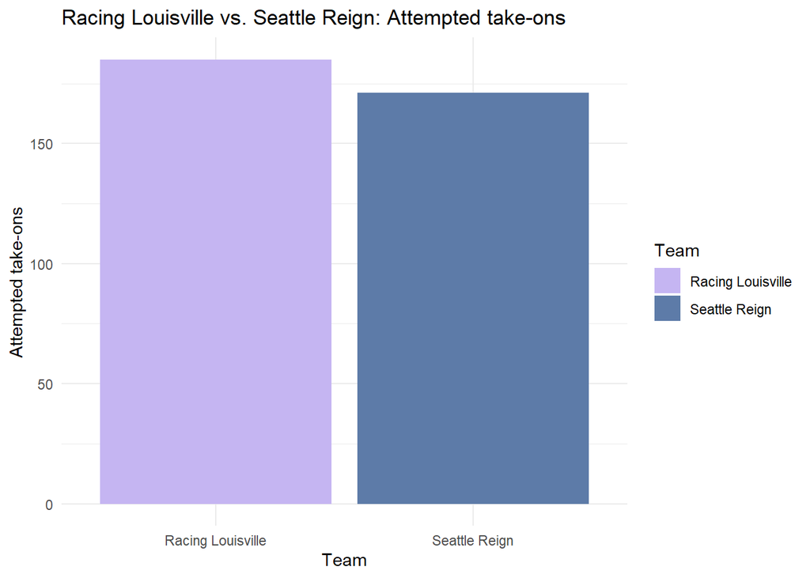

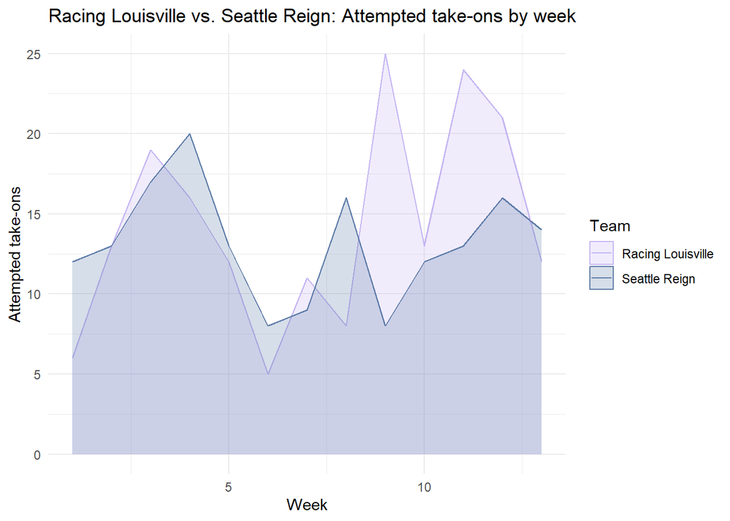

Racing Louisville is attempting more take-ons this season, but it doesn’t look like it’s by much.

| Dependent Variable | t | df | p | d | 95% CI |
| --- | --- | --- | --- | --- | --- |
| Attempted_Takeons | 0.53 | 18.69 | .302 | 0.21 | [-0.57, 0.98] |

Yeah, it’s not statistically significant, but even if it were I wouldn’t read into this too much for this comparison–there’s just too many extraneous variables here such as potentially different playing styles.

*Hypothesis test 8: Take-on success rate*

Null hypothesis: Louisville does not have a higher take-on success rate than Seattle this season.

Alternative hypothesis: Louisville has a higher take-on success rate than Seattle this season.

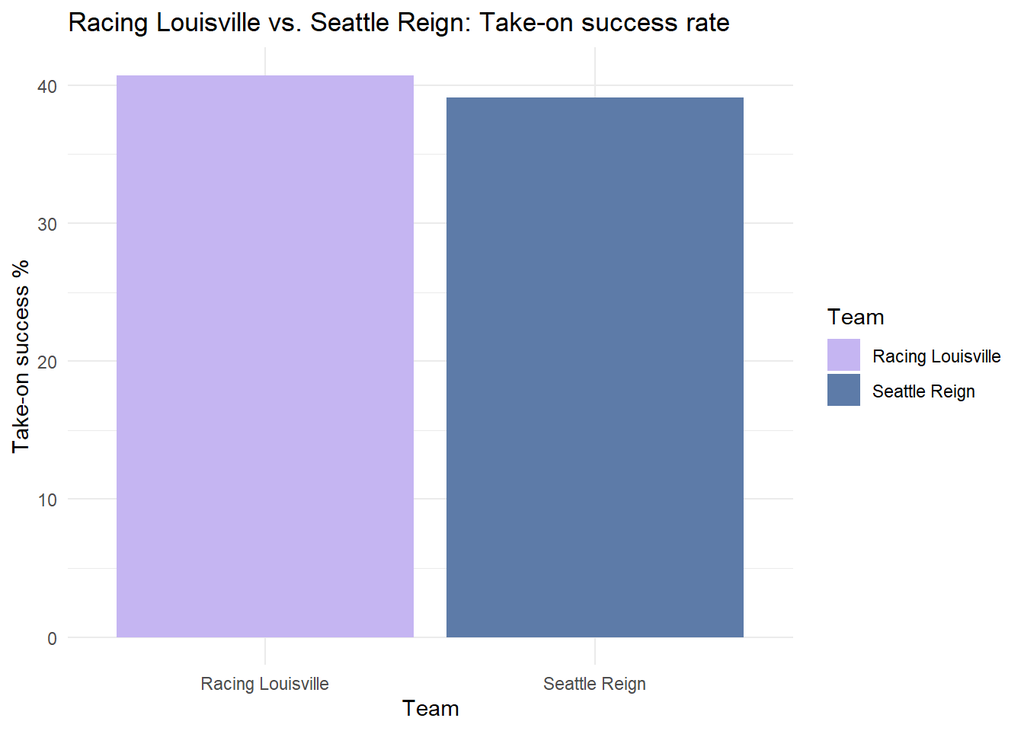

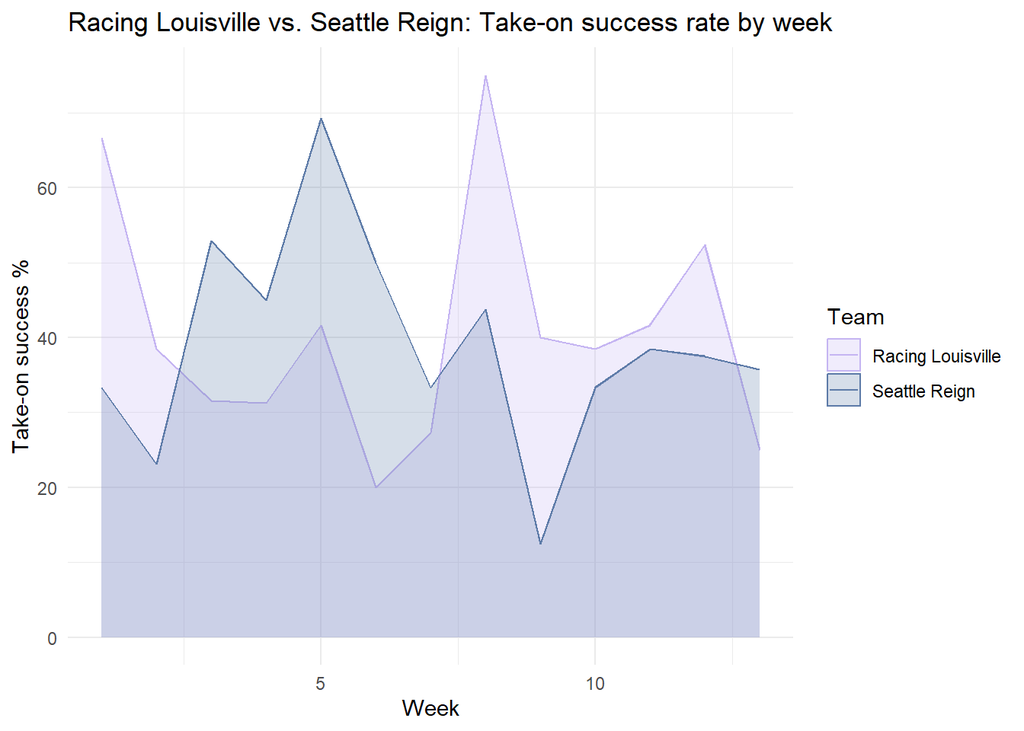

Racing Louisville has a slightly higher take-on success rate than Seattle this season.

| Dependent Variable | t | df | p | d | 95% CI |
| --- | --- | --- | --- | --- | --- |
| Successful_Takeon_Pct | 0.28 | 23.63 | .392 | 0.11 | [-0.66, 0.88] |

But just barely, and it’s not enough to be statistically significant.

My overall takeaway is that Louisville is overall doing offensively better than the Seattle Reign this season, particularly in xG generated and shots taken. In most other categories, Louisville is still doing better, just not statistically significantly so.

**Realm 2: Defense**

I also want to see if Louisville is a better defensive team than the Reign this season. The most important thing when it comes to defense is the number of goals allowed. In addition to that, I will be looking at xG and PSxG allowed, shots/shots on target allowed, tackle success rate, loose ball recoveries, times dispossessed, and errors leading to an opponent’s shot. I also want to understand if there is something fundamentally different about how Louisville is playing this season, and while data alone is far from a perfect way of answering that question, I’m going to try by looking at if there’s a difference in where on the pitch this team is winning (and therefore attempting) tackles this season.

*Hypothesis test 1: Goals allowed*

Null hypothesis: Louisville is not conceding fewer goals than Seattle this season.

Alternative hypothesis: Louisville is conceding fewer goals than Seattle this season.

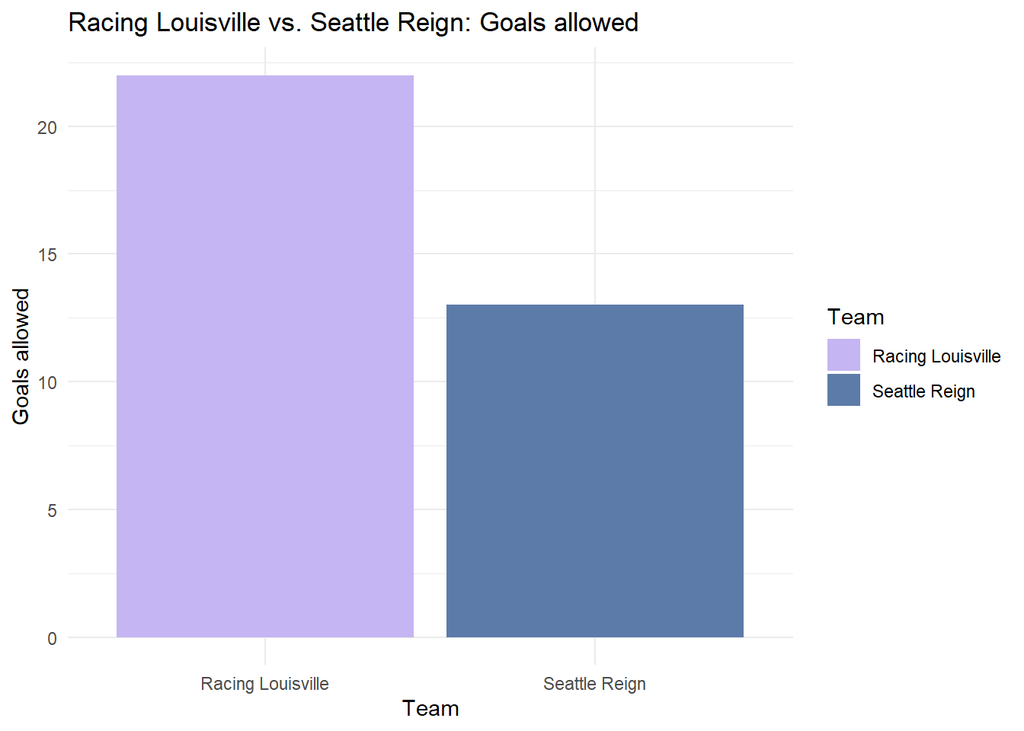

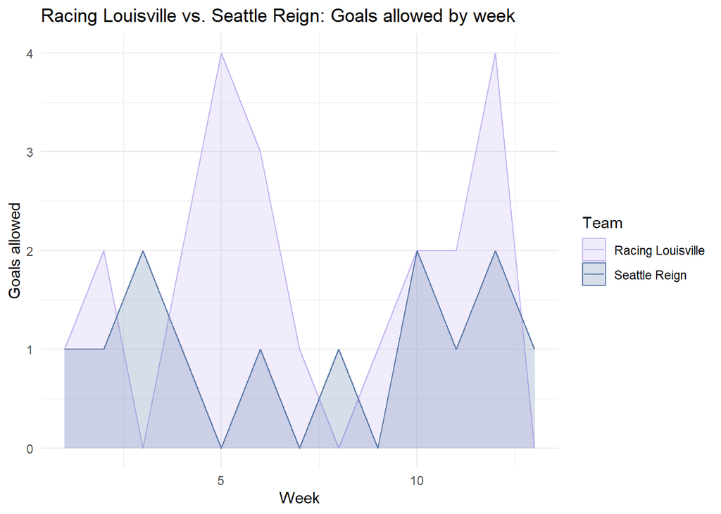

So this doesn’t bode well for Louisville’s defense–they’ve definitely conceded a lot more goals than the Reign this season.

| Dependent Variable | t | df | p | d | 95% CI |
| --- | --- | --- | --- | --- | --- |
| Goals_allowed | 1.61 | 17.91 | .938 | 0.63 | [-0.16, 1.42] |

Yikes. **Racing Louisville has conceded more goals than the Seattle Reign this season**. In the first part of this series, it seemed like Racing Louisville has been getting unlucky this season in terms of goals allowed and their other defensive statistics were a lot stronger–let’s see if that holds true when comparing against the Reign as well.

*Hypothesis test 2: xG allowed*

Null hypothesis: Louisville is not conceding less xG than Seattle this season.

Alternative hypothesis: Louisville is conceding less xG than Seattle this season.

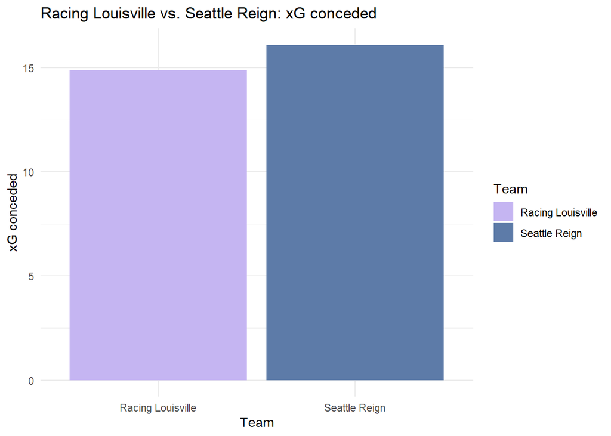

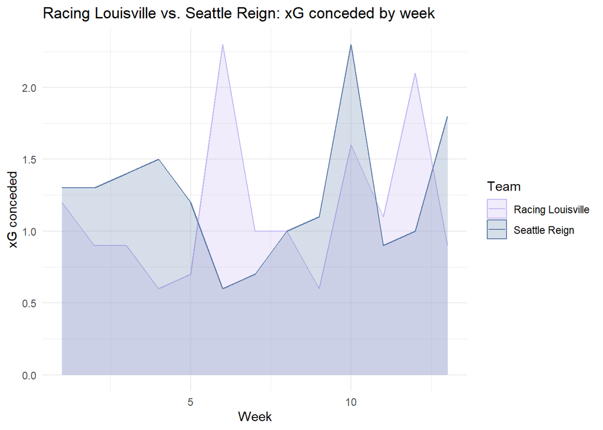

Okay, Louisville seems to be allowing less xG! Let’s look at the t-test results.

| Dependent Variable | t | df | p | d | 95% CI |
| --- | --- | --- | --- | --- | --- |
| xG_allowed | -0.47 | 23.37 | .321 | -0.19 | [-0.95, 0.59] |

So it’s not statistically significant but it’s still something.

*Hypothesis test 3: PSxG allowed*

Null hypothesis: Louisville is not conceding less PSxG than Seattle this season.

Alternative hypothesis: Louisville is conceding less PSxG than Seattle this season.

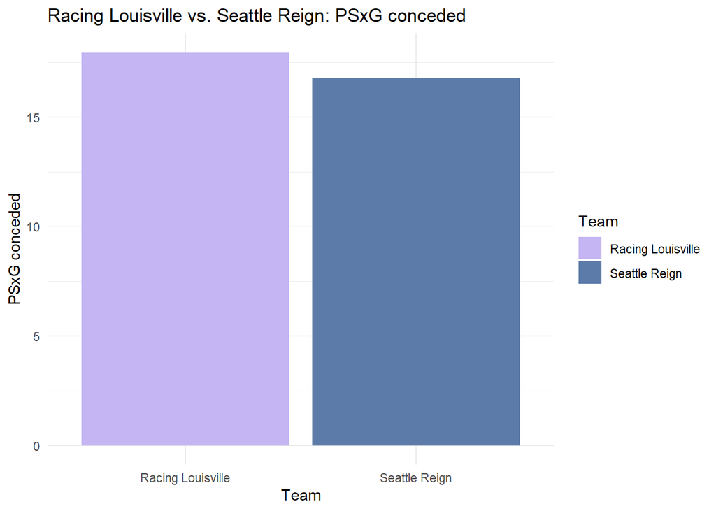

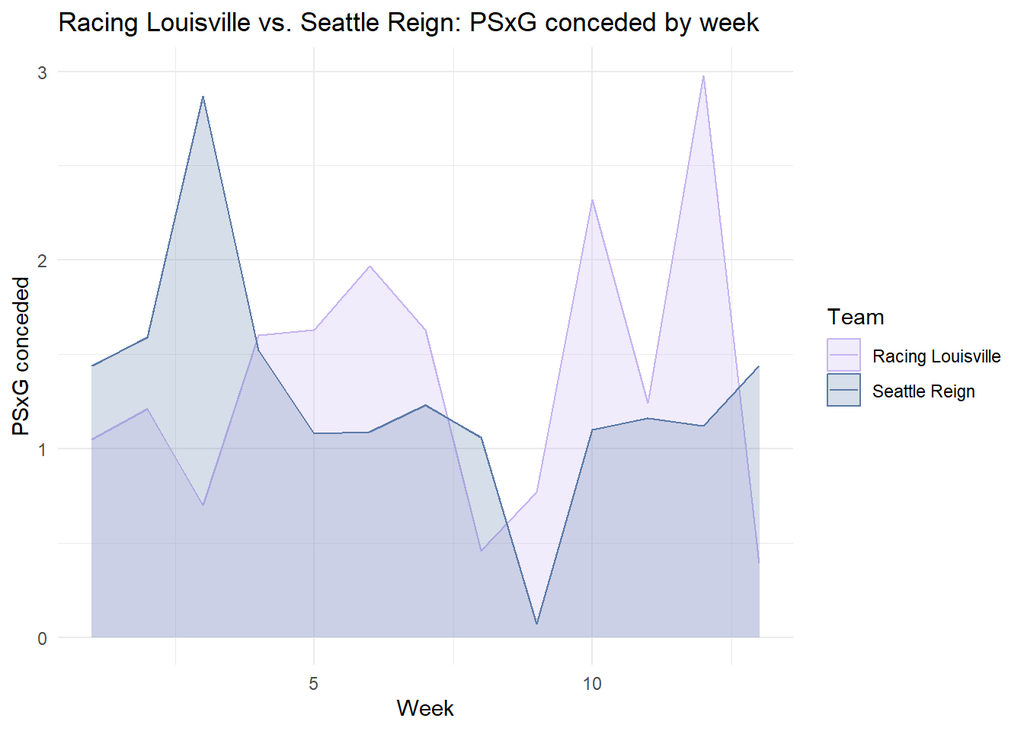

Unfortunately, Louisville is conceding more PSxG. Let’s take a look at the t-test results.

| Dependent Variable | t | df | p | d | 95% CI |
| --- | --- | --- | --- | --- | --- |
| PSxG_allowed | 0.34 | 22.95 | .631 | 0.13 | [-0.64, 0.90] |

There isn’t much to extrapolate here.

*Hypothesis test 4: Shots allowed*

Null hypothesis: Louisville is not allowing fewer shots than Seattle this season.

Alternative hypothesis: Louisville is allowing fewer shots than Seattle this season.

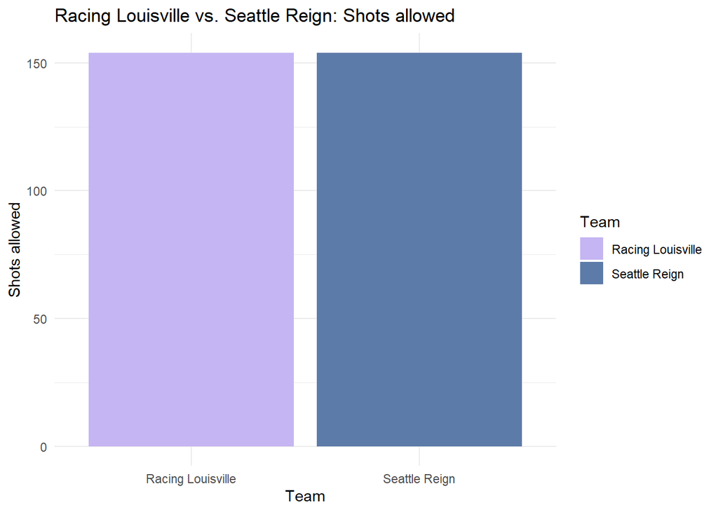

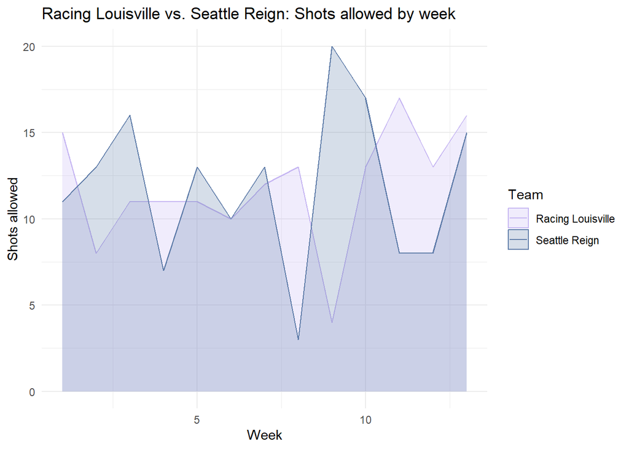

They’re neck and neck. I don’t expect the p-value to be anything other than 0.500 but let’s take a look anyway.

| Dependent Variable | t | df | p | d | 95% CI |
| --- | --- | --- | --- | --- | --- |
| Shots_allowed | 0.00 | 22.01 | .500 | 0.00 | [-0.77, 0.77] |

Yep.

Let’s take a look at the xG per shot they’re conceding though.

| Dependent Variable | t | df | p | d | 95% CI |
| --- | --- | --- | --- | --- | --- |
| xG_per_Shot | -0.81 | 21.14 | .212 | -0.32 | [-1.09, 0.46] |

Louisville is conceding less xG per shot, but it’s not enough to be statistically significant.

*Hypothesis test 5: Shots on target allowed*

Null hypothesis: Louisville is not allowing fewer shots on target than Seattle this season.

Alternative hypothesis: Louisville is allowing fewer shots on target than Seattle this season.

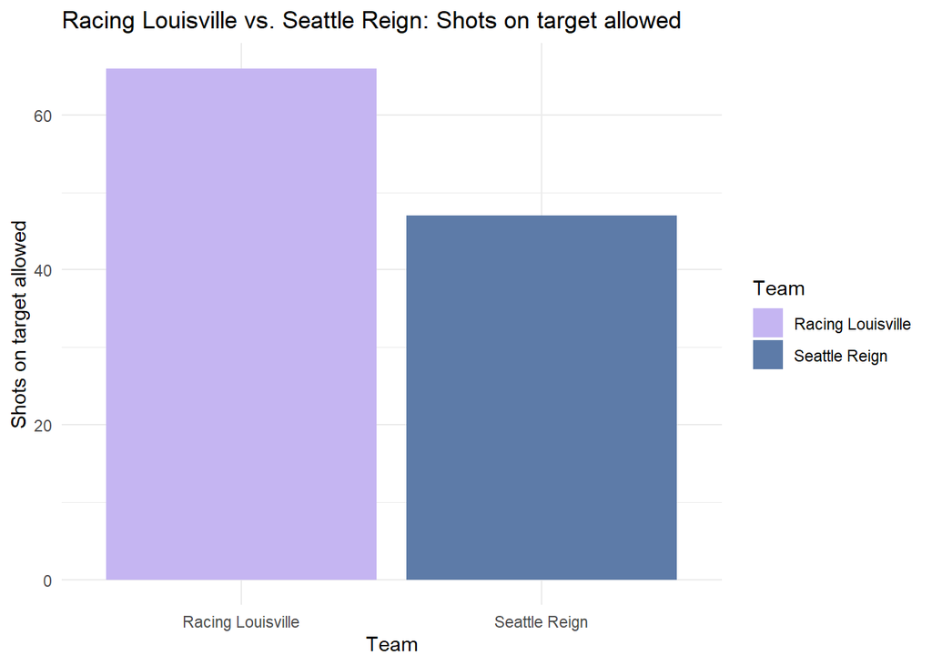

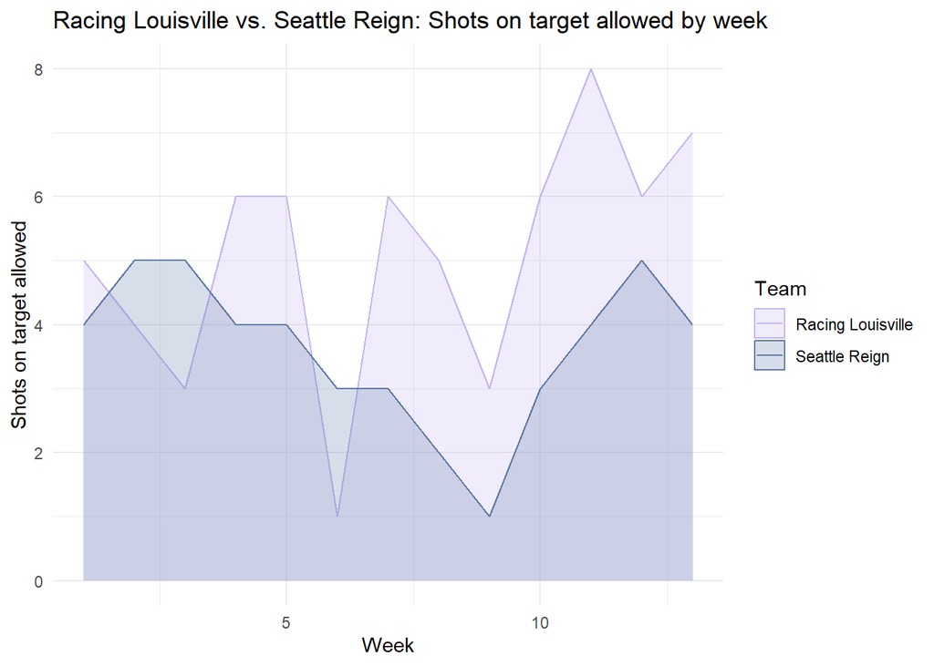

Louisville has allowed a lot more shots on target.

| Dependent Variable | t | df | p | d | 95% CI |
| --- | --- | --- | --- | --- | --- |
| Shots_on_Target_allowed | 2.36 | 20.24 | .986 | 0.92 | [0.10, 1.73] |

And statistically significantly so. Per this test, **Racing Louisville is allowing significantly more shots on target than the Seattle Reign this season**, despite allowing the same number of shots overall.

*Hypothesis test 6: Tackle win rate*

Null hypothesis: Louisville is not winning a higher percentage of their tackles than Seattle this season.

Alternative hypothesis: Louisville is winning a higher percentage of their tackles than Seattle this season.

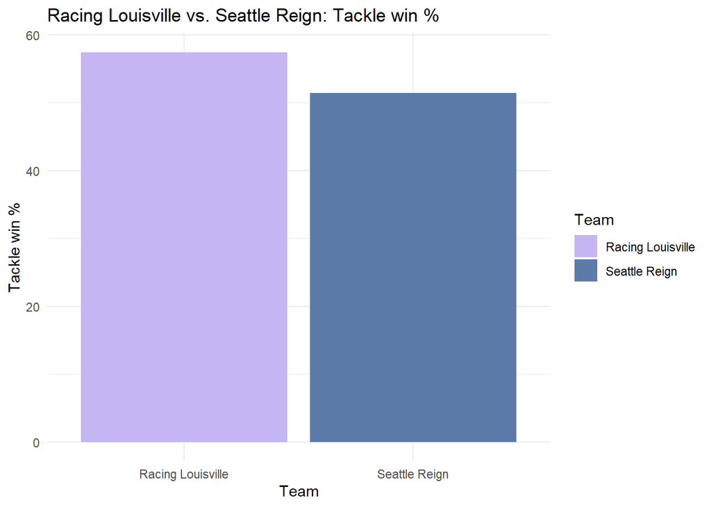

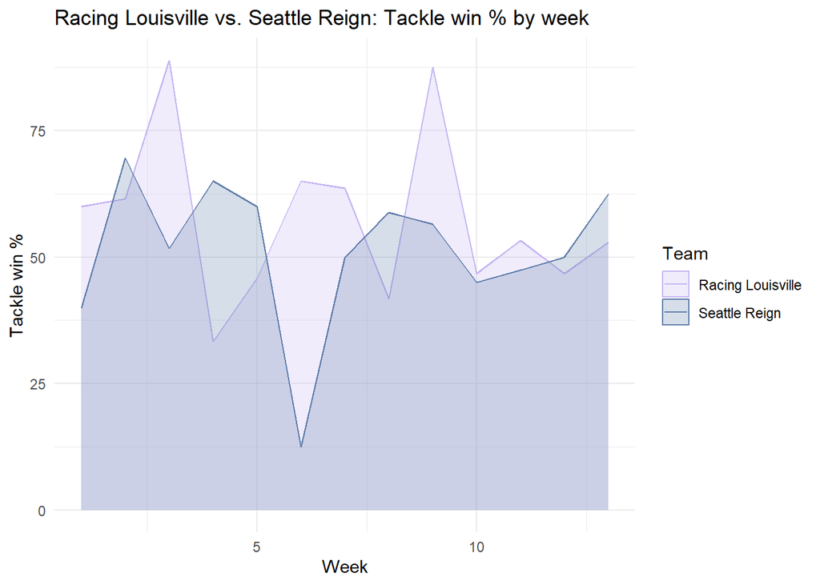

This is better from Louisville.

| Dependent Variable | t | df | p | d | 95% CI |
| --- | --- | --- | --- | --- | --- |
| Tackle_Win_Pct | 0.99 | 23.60 | .167 | 0.39 | [-0.39, 1.16] |

Not a terrible p-value there, it’s almost even statistically significant.

*Hypothesis test 7: Ball recoveries*

Null hypothesis: Louisville is not recovering more loose balls than Seattle this season.

Alternative hypothesis: Louisville is recovering more loose balls than Seattle this season.

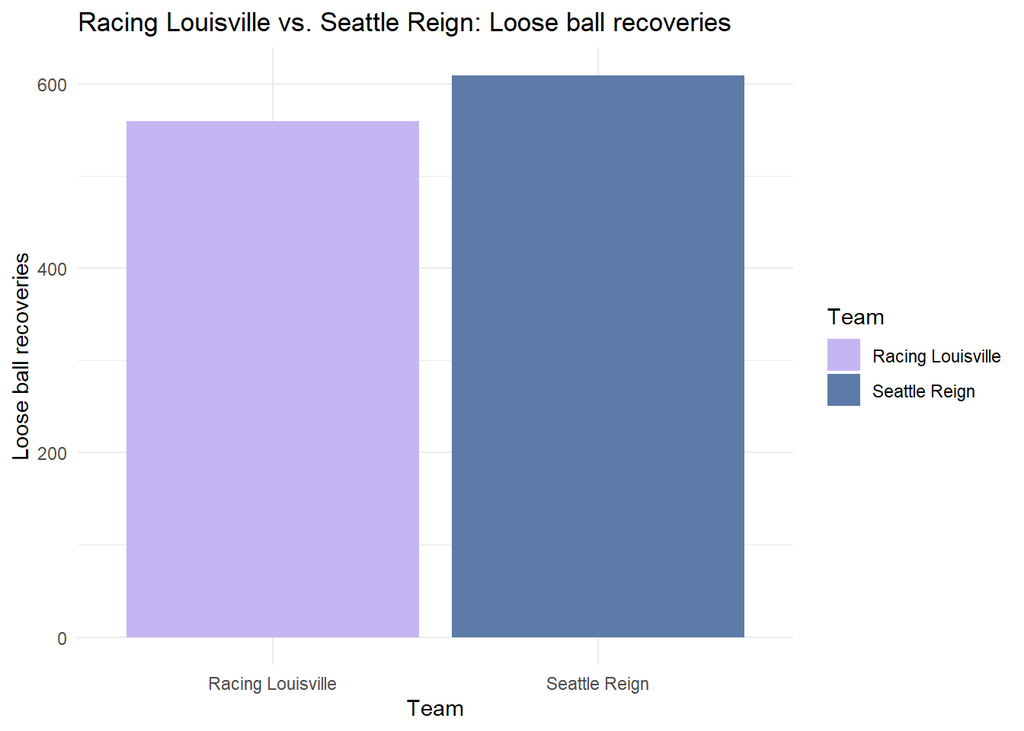

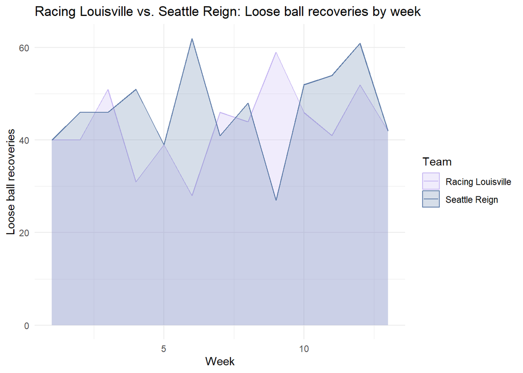

They’re recovering fewer loose balls.

| Dependent Variable | t | df | p | d | 95% CI |
| --- | --- | --- | --- | --- | --- |
| Recoveries | -1.10 | 23.57 | .858 | -0.43 | [-1.20, 0.35] |

But it’s not statistically significant. Even if it were, this statistic doesn’t matter a ton.

*Hypothesis test 8: Dispossessed*

What matters more is how much the team is dispossessed.

Null hypothesis: Louisville is not being dispossessed less than Seattle this season.

Alternative hypothesis: Louisville is being dispossessed less than Seattle this season.

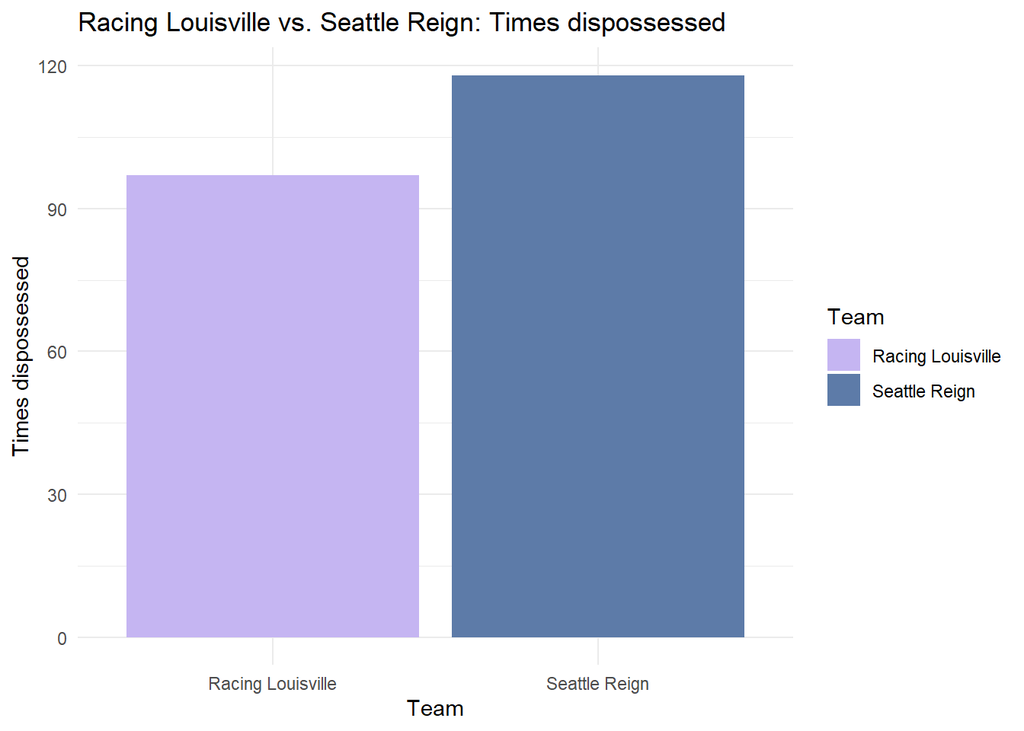

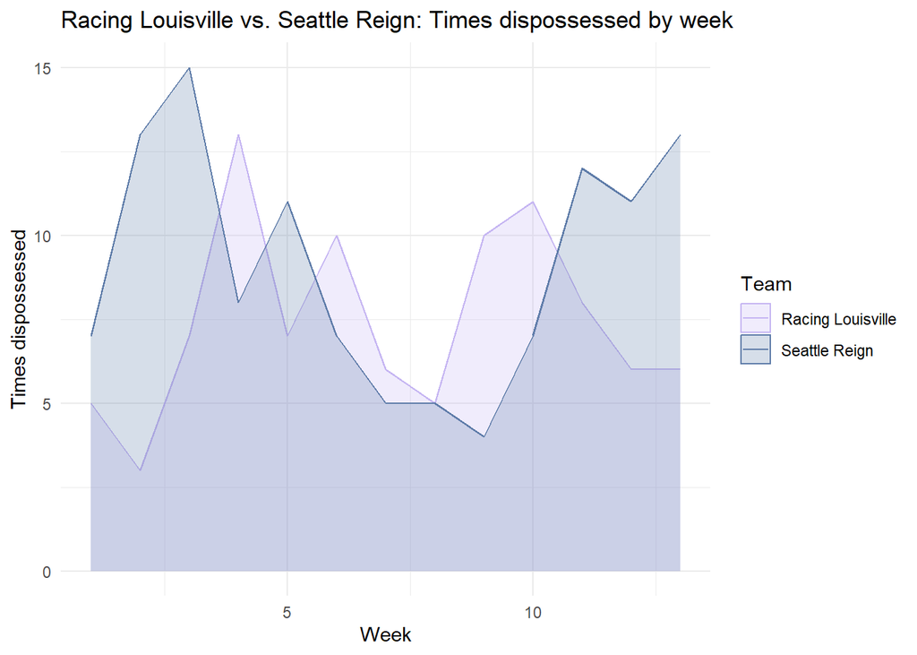

Louisville looks like they’re getting dispossessed fewer times.

| Dependent Variable | t | df | p | d | 95% CI |
| --- | --- | --- | --- | --- | --- |
| Dispossessed | -1.28 | 22.71 | .107 | -0.50 | [-1.28, 0.29] |

It’s so close to being statistically significant that I’m going to give it to them. **Racing Louisville is getting dispossessed less than Seattle this season**.

*Hypothesis test 9: Errors*

Null hypothesis: Louisville does not have fewer errors leading to opponents’ shots than Seattle this season.

Alternative hypothesis: Louisville does have fewer errors leading to opponents’ shots than Seattle this season.

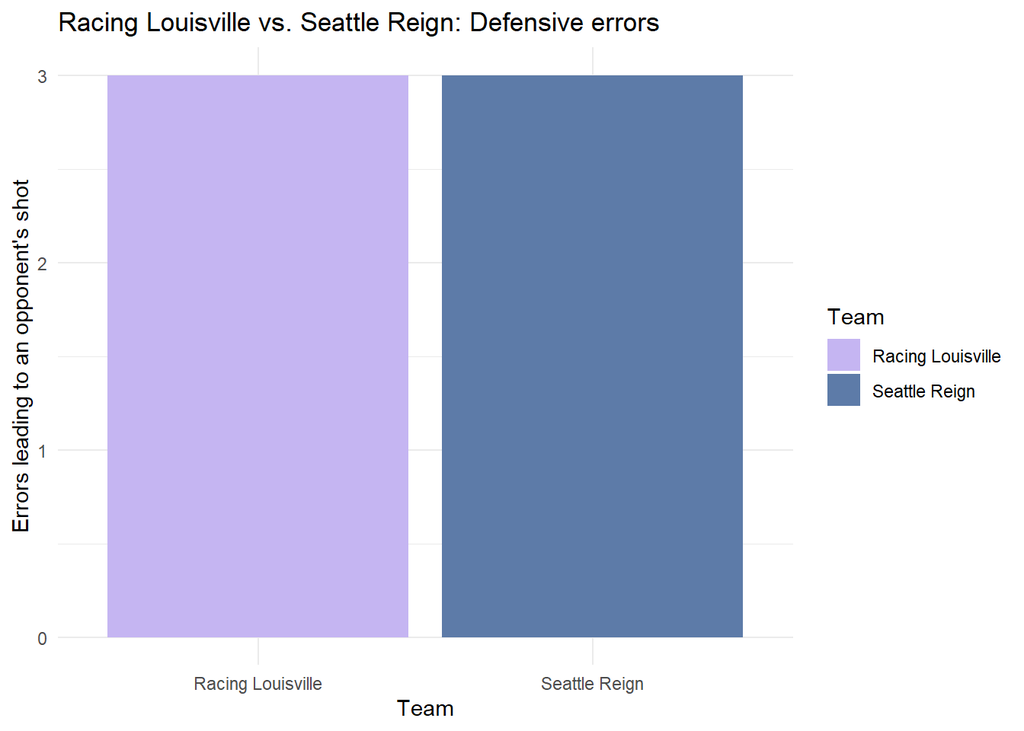

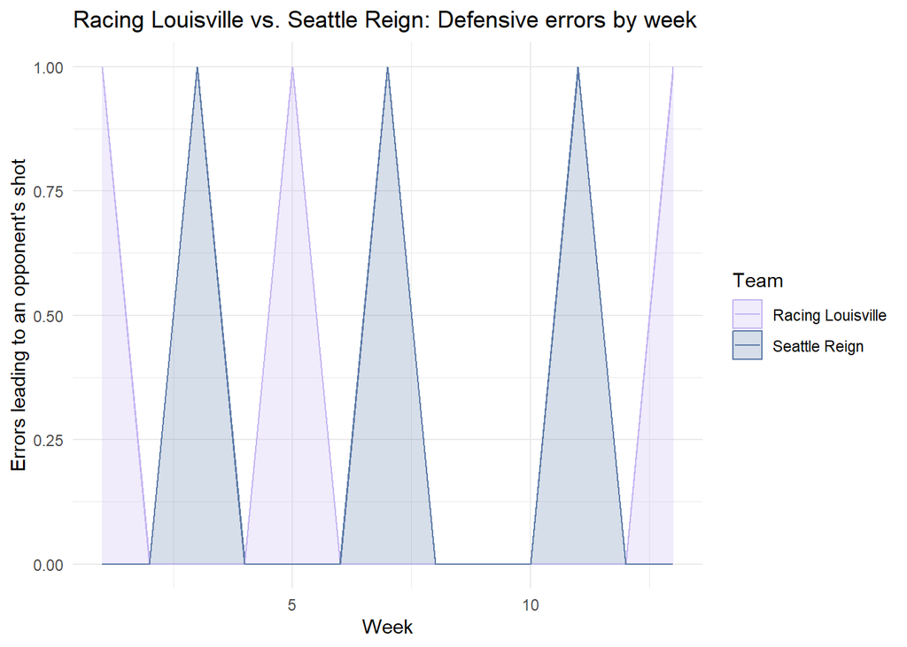

They’re neck and neck, and trading off weeks to make errors. This will be another 0.500 p-value.

| Dependent Variable | t | df | p | d | 95% CI |
| --- | --- | --- | --- | --- | --- |
| Errors | 0.00 | 24.00 | .500 | 0.00 | [-0.77, 0.77] |

Yeah, nothing to say here.